# R Notebook

# Homework Week 10 - day 2

## Question 1

Load the housing_prices.csv data set and undertake an initial exploration of the data. You will find details on the data set on the relevant Kaggle page

```r
housing_prices <- read_csv("data/housing_prices.csv")
```

## Question 2

We expect the total_rooms of houses to be strongly correlated with total_bedrooms. Use ggpairs() to investigate correlations between these two variables.

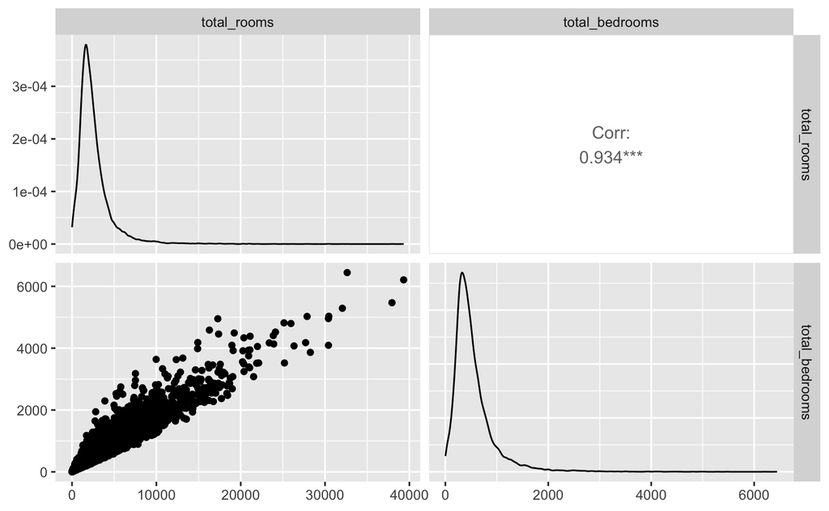

We see that there is a strong correlation between total_rooms and total_bedrooms! 0.9!

## Question 3

So, we do find significant correlations. Let’s drop total_bedrooms from the dataset, and use only total_rooms going forward.

## Question 4

We are interested in developing a regression model for the median_house_value of a house in terms of the possible predictor variables in the dataset.

### subq I

Use ggpairs() to investigate correlations between median_house_value and the predictors (this may take a while to run, don’t worry, make coffee or something).

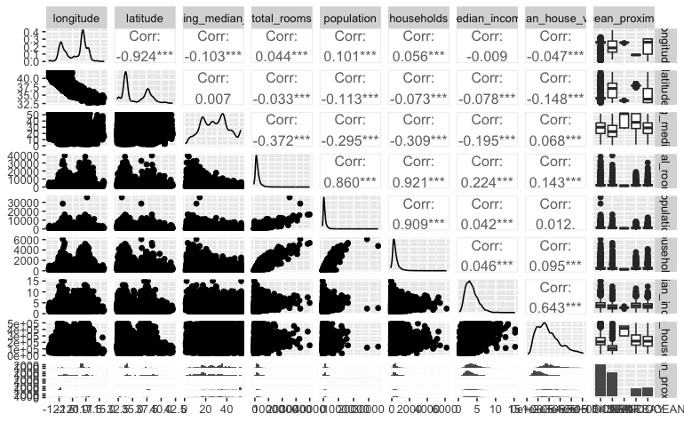

So from ggpairs, we see that strongest correlation (with median_house_value) is found with: 1. median_income (0.643)

### subq II

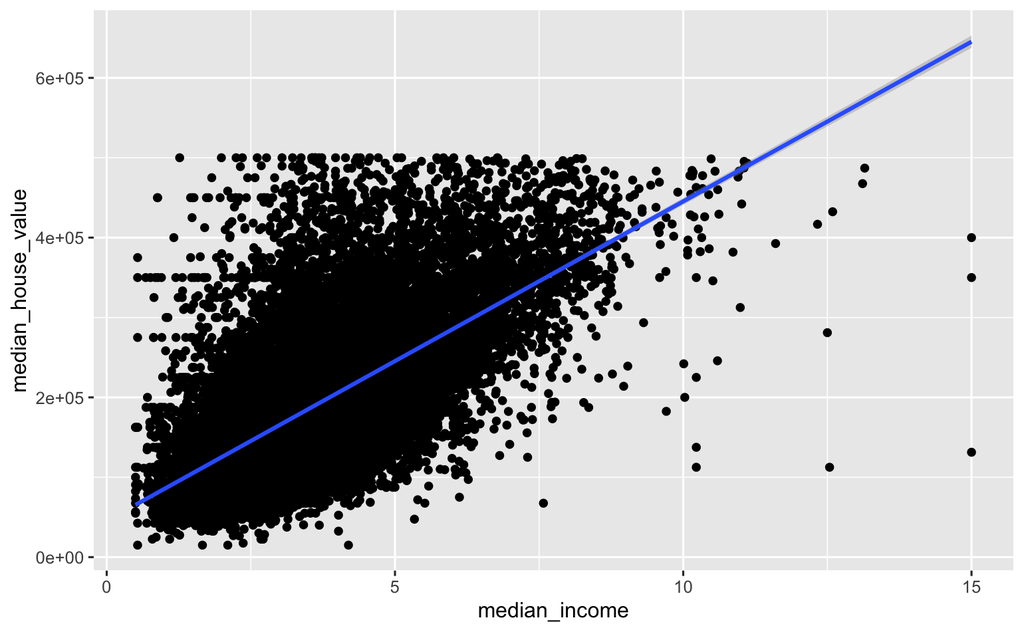

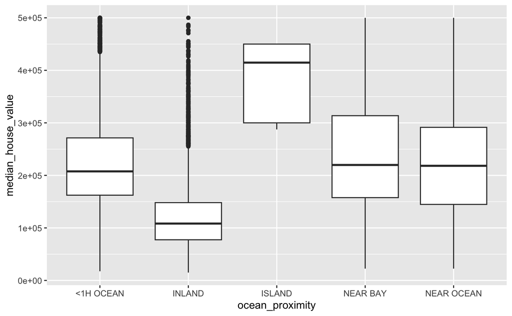

## Question 5

Shortly we may try a regression model to fit the categorical predictor ocean_proximity. Investigate the level of ocean_proximity predictors. How many dummy variables do you expect to get from it?

| ocean_proximity | total_rows |
| --- | --- |
| <1H OCEAN | 8604 |
| INLAND | 6524 |
| ISLAND | 5 |
| NEAR BAY | 2096 |
| NEAR OCEAN | 2446 |

So there are 5 distinct values for the variable ocean_proximity. We therefore only need 4 dummy variables in total.

The `Island` variable category has only sow few instances, so we can combine it with `Near Ocean`

So we will than only need 3 dummy variables in total.

## Question 6

Start with simple linear regression. Regress median_house_value on median_income and check the regression diagnostics.

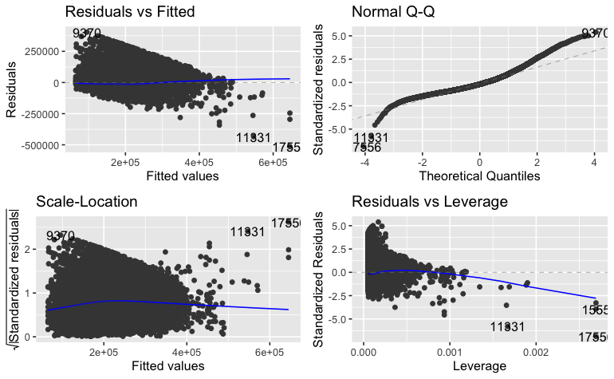

*Based on plots:* - 1st plot, we expect a straight blue line around zero. This seems to be the case, but not all points are equally distributed around it. indicating that pattern in data is closely resembling a linear relation. I think that there is such a strong border between residuals and not because the house_value does not go higher than a certain number

- The p-value indicates that there is reason to reject H0, indicating that there is a very high reason to believe the relationship is significant.
- And the intercept is at 45457

## Question 7

Add another predictor of your choice. Check your assumptions, diagnostics, and interpret the model.

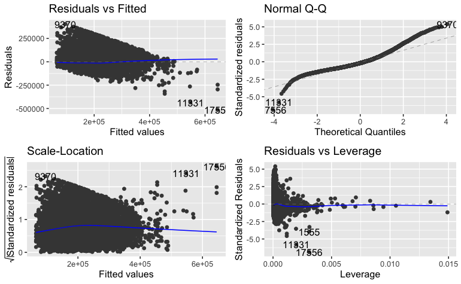

```r
summary(model_2)
```

```
Call:
lm(formula = median_house_value ~ median_income + total_rooms,
    data = house_price)

Residuals:
    Min      1Q  Median      3Q     Max
-514229  -51548  -13949   36541  403882

Coefficients:
                Estimate Std. Error t value Pr(>|t|)
(Intercept)    4.552e+04  1.409e+03  32.318   <2e-16 ***
median_income  4.000e+04  3.488e+02 114.679   <2e-16 ***
total_rooms   -4.428e-02  2.511e-01  -0.176     0.86
---
Signif. codes:  0 ‘***’ 0.001 ‘**’ 0.01 ‘*’ 0.05 ‘.’ 0.1 ‘ ’ 1

Residual standard error: 74870 on 19672 degrees of freedom
Multiple R-squared:  0.4129,    Adjusted R-squared:  0.4129
F-statistic:  6919 on 2 and 19672 DF,  p-value: < 2.2e-16
```

- The estimate column shows us that: -> every unit increase in median_income = 4.000e+04 increase in y -> every unit increase in total_rooms = -4.428e-02 decrease in y

  ```
      --->>> HOW??? ASK??! In GGpairs, we saw its a positive correlation! But actually not significant!
  ```

- The p-value indicates that: -> For median income there is reason to reject H0, indicating that there is a very high reason to believe the relationship is significant. -> For total_rooms, p-value is high, and we cannot reject H0: = no significant relation.
- And the intercept is at 4.552e+04

Based on the answers:

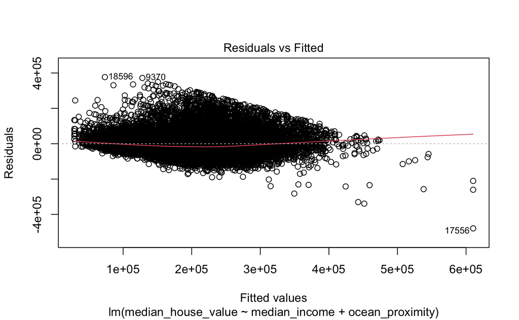

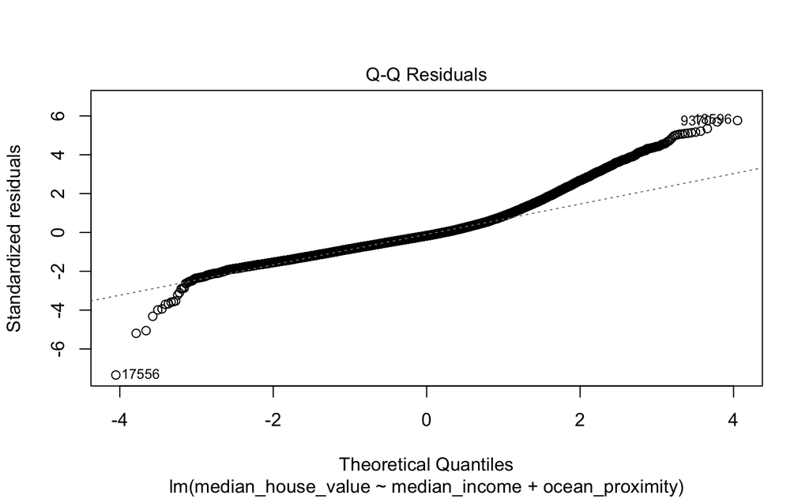

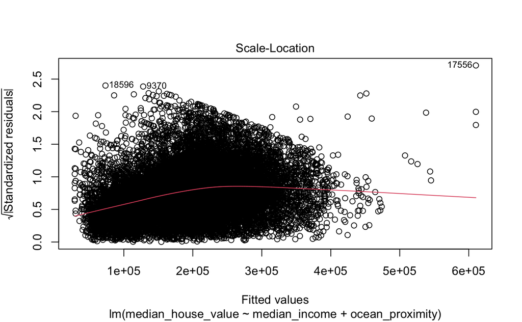

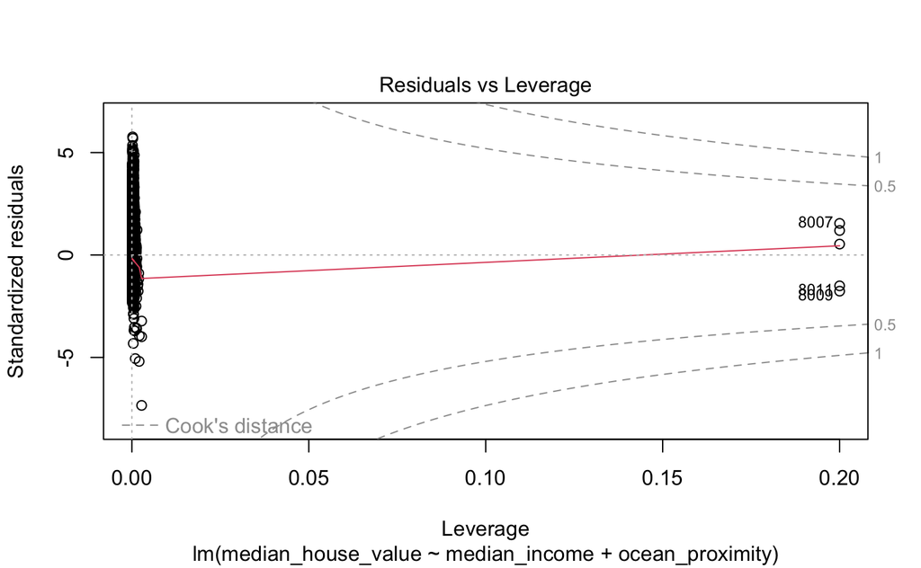

`r # The predictors median income and ocean_proximity explains 55% of the variation # in the median_house_value. In addition, these predictors are also significant. # For every increase in median income by 1 unit, the median house price increases # by 35118.0 if all other predictors remain the same. If the house is on an island, # the median house price increases by 200,480.2 if all other predictors remain the same.`